# Capstone Milestone Report One

# Milestone Report One - JLG Oct 21

A progress report on a Natural Language Processing capstone project

## Data

Restricting ourselves to the “English” data, we have three documents. Twitter, Blogs, and News. Each file contains a string per line, where each line is an ‘entry’. For all files, the length of these strings varies, however we should note that Twitter entries, ‘tweets’ are limited to 280-characters (140 prior to the increase)

## Exploratory Analysis

We can see some distinct differences between these documents with the following summary.

| document | lines | total_words | mean_words | sd_words | min_words | max_words |
| --- | --- | --- | --- | --- | --- | --- |
| en_US.blogs.txt | 899288 | 37334131 | 41.51521 | 46.271282 | 1 | 6630 |
| en_US.news.txt | 77259 | 2643969 | 34.22215 | 22.820202 | 1 | 1031 |
| en_US.twitter.txt | 2360148 | 30373583 | 12.86936 | 6.903741 | 1 | 47 |

Blogs has the most words, yet the second-most entries, and with the largest mean number of words per entry. That is, the entries tend to have more words than any other document. However the high standard-deviation means they are more variable overall. Understandably, Twitter is the most restricted, however the ease of collection means we have the most entries. This restriction also reflects the smaller standard-deviation in number of words.

We can see these differences in distributions better with the following plot.

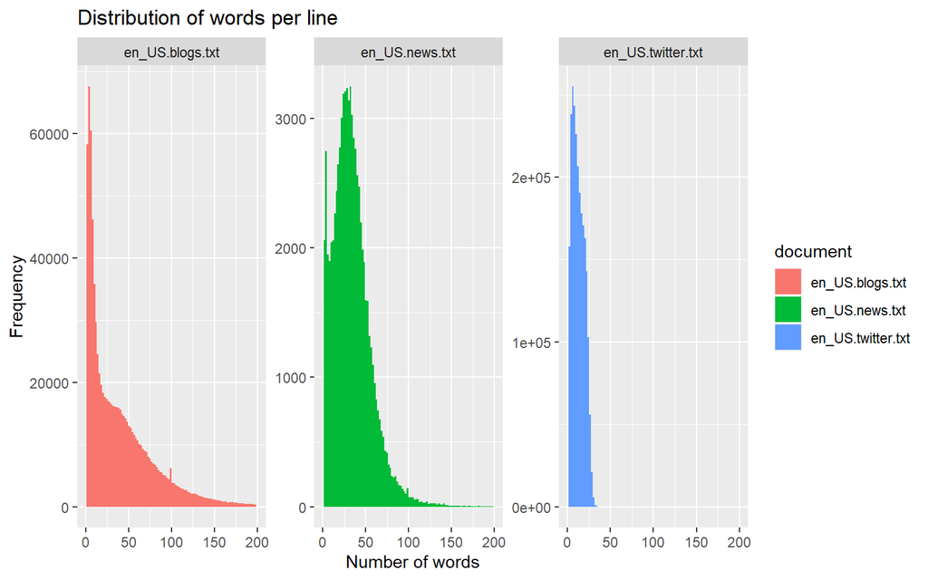

For all documents, we have a large number of documents with very few words. Whilst this is expected for Twitter, both Blogs and News have large peaks at the lower numbers also. This is most likely due to summaries and titles that have been obtained, over full articles. We can also investigate the most frequently used words for each document.

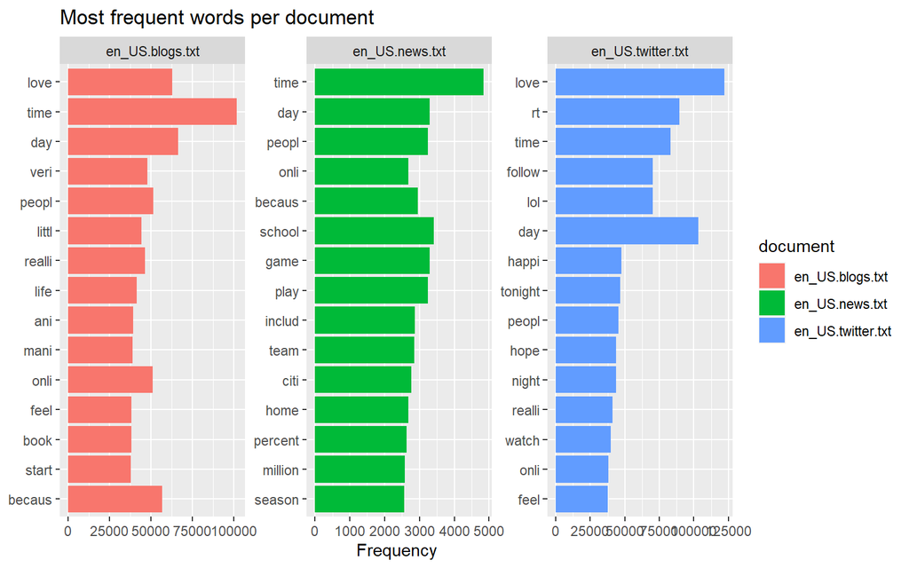

We can see that Blogs have a focus on time (time, day, start) and on personal connections (love, people, life, feel). News also has a focus on time (time, day, season) but more business (citi, percent, season, team) and culture links (people, school, home). Twitter, much alike Blogs, has a strong focus on time (time, day), personal (happi, people, hope, feel) and inter-account connections (rt [retweet], follow). As one may expect, both Twitter and Blogs appear much more personal than the News.

Looking further at most frequent bigrams and trigrams, we can create complementary plots for analysis.

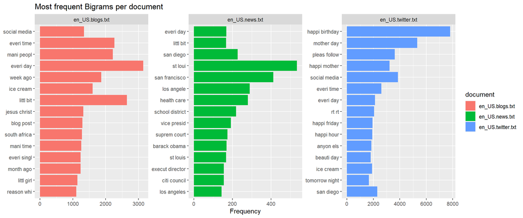

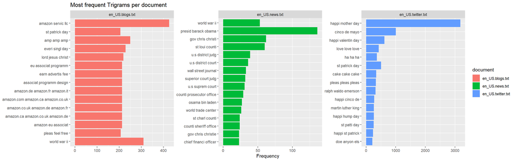

We can see that both Twitter and Blogs still focus on personal and time-like n-grams, and News becomes even more so politically and financially focused. Trigrams are mostly dominated by holidays and special-occasions for Twitter. However, for blogs, this is dominated by sponsorship and tags of popular sites commonly used for hosting blogs.

Looking at the ‘Term-Frequency / Inverse-Document-Frequency’ (how “unique” a word is to that document) for each document, we have the following.

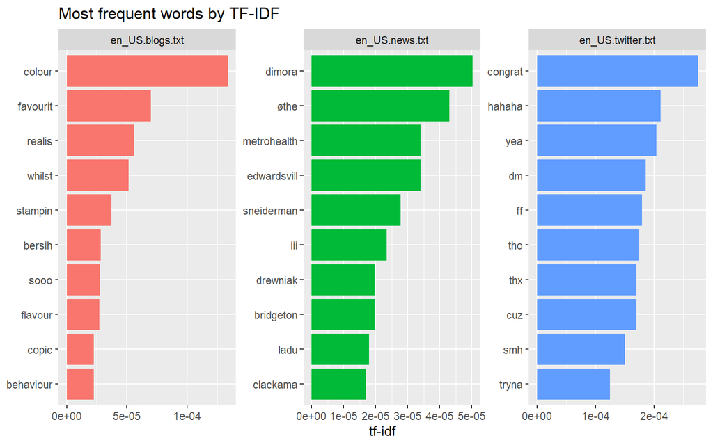

| document | n 25% | n 50% | n 75% | n 90% | n 100% |
| --- | --- | --- | --- | --- | --- |
| en_US.blogs.txt | 218 | 944 | 3822 | 13990 | 267553 |
| en_US.news.txt | 253 | 1007 | 3817 | 12793 | 69737 |
| en_US.twitter.txt | 125 | 683 | 3179 | 12963 | 320200 |

This table shows us the number of words, sorted by frequency, needed to cover the whole document. Twitter needs the fewest words to cover half of the document, but all converge to relatively similar amounts to attain the higher percentage coverage. It may be possible to improve this, but including a dictionary of the most common words of the English language, on top of these documents. However, we’ll leave that as exploration for future optimisation.

Lastly, if we inspect the Parts Of Speech for each document, we can gain a further insight into the types of writing that occurs in each. We can use the following table to understand each ‘tag’.

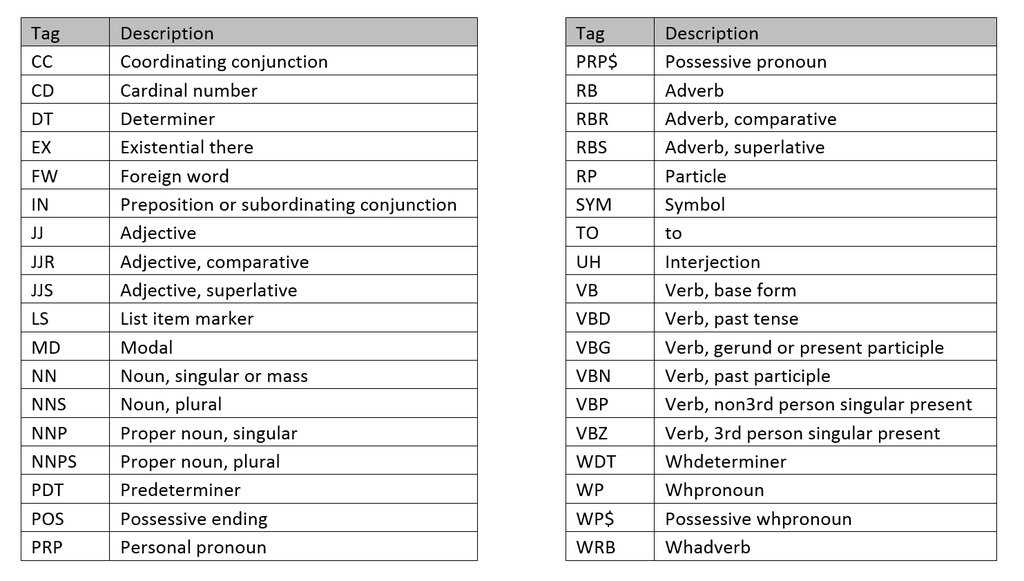

Parts Of Speech tags

Plotting the counts of each of these,

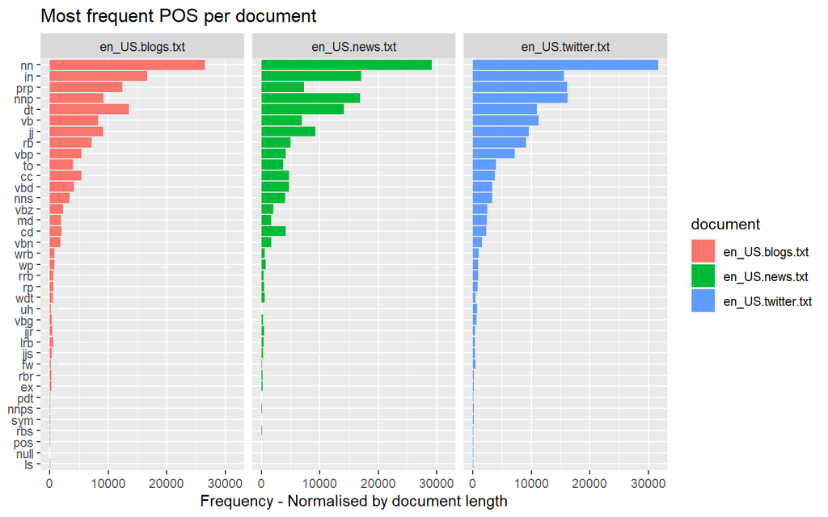

```r
POS_summary_df %>% group_by(document) %>%
  mutate(PFreq = total/n()) %>%
  arrange(PFreq) %>%
  ggplot(aes(x = PFreq, y = fct_reorder(POS, PFreq), fill = document)) +
  geom_col() +
  facet_wrap(~document, scales = 'fixed') +
  labs(title = "Most frequent POS per document", y = NULL, x = "Frequency - Normalised by document length")
```

## Goals

From calculating the above, we already have a lot of functions that are useful going forward. Especially so with the fact that one goal is to be able to apply this method to any folder of text documents. To present these clearly, the following goals are kept in mind

- Utilise functions to ensure reproducibility
- Employ efficient algorithms to counteract file size
- Calculate Markov Chain probabilities of unigrams, bigrams, and trigrams for modelling
- Create a function that uses the above to predict the next word from a string of any length
- Create a function that can append a ‘list of strings’ to the probabilities matrix and ‘update’ it
- Possible sentiment analysis from a line of text, leading to overall sentiment analysis of a document.
- Research appropriate ways to measure accuracy of predictions